# P8105 HW 1 EP3045

2022-09-23

#Problem 1

```r
library(palmerpenguins)
data("penguins", package = "palmerpenguins")
```

The names: species, island, bill_length_mm, bill_depth_mm, flipper_length_mm, body_mass_g, sex, year.

The unique *species*: Adelie, Gentoo, Chinstrap.

The unique *islands*: Torgersen, Biscoe, Dream.

The unique *years*: 2007, 2008, 2009.

The *sex* of the penguins: male, female.

The mean for *bill length* is 43.92mm, and the standard deviation is 5.46.

The mean for *bill depth* is 17.15mm, and the standard deviation is 1.97.

The mean for *flipper length* is 201mm, and the standard deviation is 14.06.

There are 344 *rows* and 8 *columns* in this dataset.

#### Creating a scatter plot

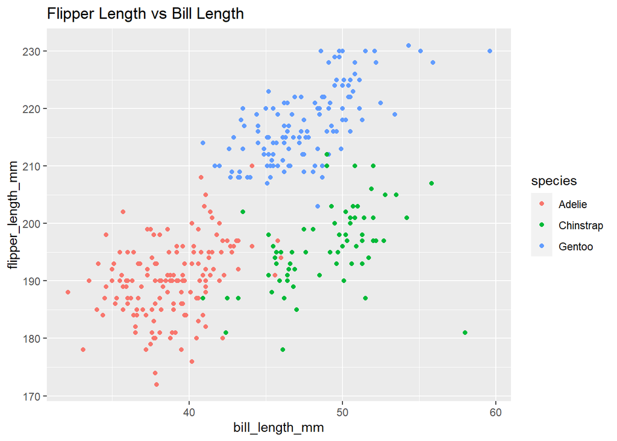

```r
ggplot(penguins,aes(x = bill_length_mm, y = flipper_length_mm, color = species)) + geom_point() + ggtitle("Flipper Length vs Bill Length")
```

```r
#This is the scatter plot for Flipper versus Bill Length.
```

#### Saving the scatter plot

```r
ggsave("penguin_scatter.pdf", plot = last_plot(), height = 4, width = 6)
```

#### Creating a data frame that consists of numeric, logical, character, and factor vectors.

```r
set.seed(420)
data_table <- tibble(
  my_variable = rnorm(10),
  logical_vec = my_variable > 0,
  ten_char_vector = c("s", "t", "r", "a", "w", "b", "e", "r", "r", "y"),
  three_levels = factor(c("small", "medium", "large", "large", "medium", "small", "medium", "small", "large", "medium"))
)
data_table
```

```
## # A tibble: 10 × 4
##    my_variable logical_vec ten_char_vector three_levels
##          <dbl> <lgl>       <chr>           <fct>
##  1       0.268 TRUE        s               small
##  2      -0.937 FALSE       t               medium
##  3       0.596 TRUE        r               large
##  4      -0.312 FALSE       a               large
##  5       0.398 TRUE        w               medium
##  6      -0.515 FALSE       b               small
##  7      -0.552 FALSE       e               medium
##  8      -0.461 FALSE       r               small
##  9      -2.95  FALSE       r               large
## 10      -0.767 FALSE       y               medium
```

#### Attempting to take the means of the variables

```r
mean(pull(data_table, my_variable))
```

```
## [1] -0.5229955
```

```r
mean(pull(data_table, logical_vec))
```

```
## [1] 0.3
```

```r
mean(pull(data_table, ten_char_vector))
```

```
## [1] NA
```

```r
mean(pull(data_table, three_levels))
```

```
## [1] NA
```

The variables “my_variable” and “logical_vec” are numeric and logical vectors. Because of this, we are able to calculate their means. The variables “ten_char_vector” and “three_levels” are character and factor vectors. Because of this, we cannot calculate their means.

#### Converting logicial, character, and factor variables using as.numeric without showing the outputs

```r
converted_num1 = as.numeric(pull(data_table, logical_vec))
converted_num2 = as.numeric(pull(data_table, ten_char_vector))
converted_num3 = as.numeric(pull(data_table, three_levels))
```

#### Finding the means of the converted variables

```r
mean(converted_num1)
```

```
## [1] 0.3
```

```r
mean(converted_num2)
```

```
## [1] NA
```

```r
mean(converted_num3)
```

```
## [1] 2
```